# Reproducible Research-Project 1

Sameer Sharma

March 20, 2018

We first start by reading the CSV file

```r
activity_raw<-read.csv("activity.csv",
                       stringsAsFactors=FALSE)
```

Let us ensure that the dates in the dataset are well understood by R as being dates themselves!

```r
activity_raw$date <- as.Date(activity_raw$date)
```

What is mean total number of steps taken per day?

Q1: Calculate total Number of Steps Per Day

```r
total_steps_per_day<- tapply(activity_raw$steps,
                             activity_raw$date,sum)
```

Q2: Histogram of Steps Taken Each Day

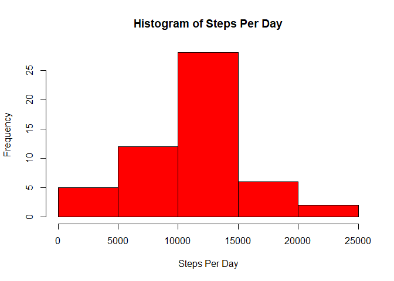

```r
hist(total_steps_per_day,xlab="Steps Per Day", main =
       "Histogram of Steps Per Day",col="red")
```

Q3: Calculate and report the mean and median of the total number of steps taken per day

```r
MeanPerDay <- mean(total_steps_per_day, na.rm = TRUE)
MedianPerDay <- median(total_steps_per_day, na.rm = TRUE)
print(MeanPerDay)
```

```
## [1] 10766.19
```

```r
print(MedianPerDay)
```

```
## [1] 10765
```

The mean steps per day=10766.19 and Median steps per day=10765

What is the Average Daily Pattern?

Q1: Make a time series plot of the 5-minute interval and the average number of steps taken, averaged across all days

```r
stepsperint<-tapply(activity_raw$steps,activity_raw$interval,
                    mean,
                    na.rm=T)
```

Let us plot this now

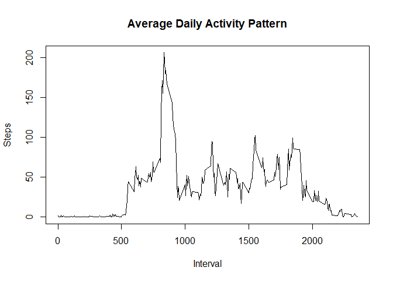

```r
plot(as.numeric(names(stepsperint)),
     stepsperint,
     xlab = "Interval",
     ylab = "Steps",
     main = "Average Daily Activity Pattern",
     type = "l")
```

Q2: Which 5-minute interval, on average across all the days in the dataset, contains the maximum number of steps?

```r
rank<-sort(stepsperint,decreasing = T)
head(rank,1)
```

```
##      835
## 206.1698
```

At 835th interval, max steps is 206.1698

Imputing missing values Note that there are a number of days/intervals where there are missing values (coded as NA). The presence of missing days may introduce bias into some calculations or summaries of the data.

Q1: What is the number of missing values in the dataset?

```r
sum(is.na(activity_raw$steps))
```

```
## [1] 2304
```

There are 2304 missing step values in the raw dataset.

Q2: Devise strategy to fill in missing values We will use ImputeTS package to fill in missing values

```r
require(imputeTS)
activity<-na.interpolation(activity_raw)
```

Q3: Histogram of steps taken each day and mean and median

```r
total_steps<-tapply(activity$steps,activity$date,sum)
```

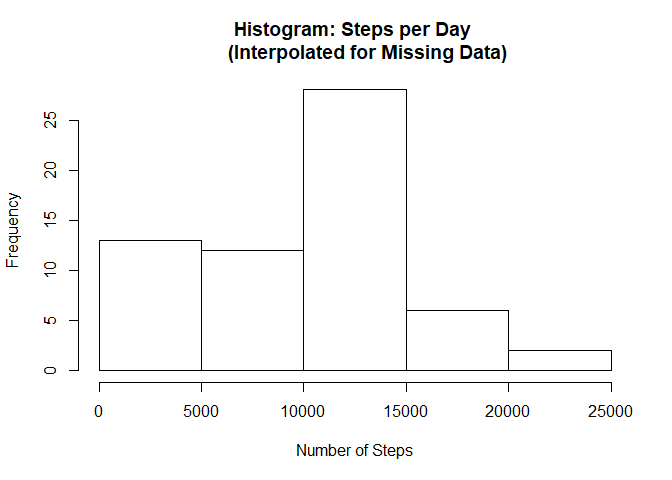

```r
hist(total_steps,
     xlab = "Number of Steps",
     main =
       "Histogram: Steps per Day
     (Interpolated for Missing Data)")
```

```r
MeanPerDay_interpolated <- mean(total_steps, na.rm = TRUE)
MedianPerDay_interpolated <- median(total_steps, na.rm = TRUE)
print(MeanPerDay_interpolated)
```

```
## [1] 9354.23
```

```r
print(MedianPerDay_interpolated)
```

```
## [1] 10395
```

Given the interpolation methodology used, we note changes to the mean and median wherein Mean Steps= 9354.23 Median Steps= 10395

Are there differences in activity patterns between weekdays and weekends?

Q1: Seperating data into weekdays or weekends Here we will use ifelse statement

```r
activity$day <- ifelse(weekdays
                       (as.Date(activity$date)) ==
                         "Saturday" |
                         weekdays(as.Date(activity$date))
                       == "Sunday", "weekend", "weekday")
```

Q2: Average Steps/Interval Weekends vs Weekdays We need to also make a pannel plot

```r
stepsperintweekend <- tapply(activity[activity$day
                          == "weekend" ,]$steps,
                    activity[activity$day == "weekend" ,]$interval, mean,
                          na.rm = TRUE)

stepsperintweekday <- tapply(activity[activity$day
                                      == "weekday" ,]$steps,
                             activity[activity$day == "weekday" ,]$interval, mean,
                             na.rm = TRUE)
```

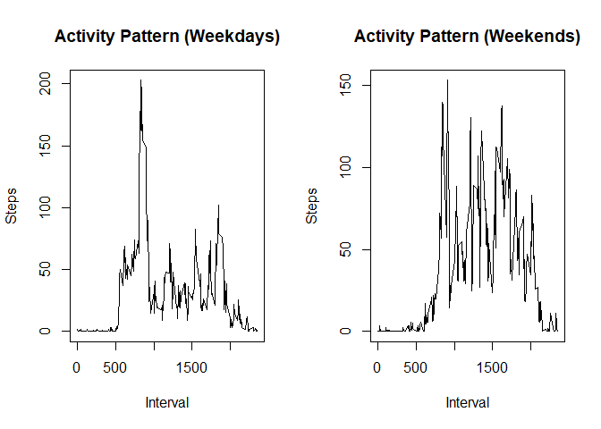

```r
par(mfrow=c(1,2))

plot(as.numeric(names(stepsperintweekday)),
     stepsperintweekday,
     xlab = "Interval",
     ylab = "Steps",
     main = "Activity Pattern (Weekdays)",
     type = "l")


plot(as.numeric(names(stepsperintweekend)),
     stepsperintweekend,
     xlab = "Interval",
     ylab = "Steps",
     main = "Activity Pattern (Weekends)",
     type = "l")
```

We can clearly see that weekend activity is higher than weekday activity.